# Inference for numerical data

## Getting Started

### Load packages

In this lab, we will explore and visualize the data using the **tidyverse** suite of packages, and perform statistical inference using **infer**. The data can be found in the companion package for OpenIntro resources, **openintro**.

Let’s load the packages.

```r
library(tidyverse)
library(openintro)
library(infer)
```

### Creating a reproducible lab report

To create your new lab report, in RStudio, go to New File -> R Markdown… Then, choose From Template and then choose `Lab Report for OpenIntro Statistics Labs` from the list of templates.

### The data

Every two years, the Centers for Disease Control and Prevention conduct the Youth Risk Behavior Surveillance System (YRBSS) survey, where it takes data from high schoolers (9th through 12th grade), to analyze health patterns. You will work with a selected group of variables from a random sample of observations during one of the years the YRBSS was conducted.

Load the `yrbss` data set into your workspace.

```r
data(yrbss)
```

There are observations on 13 different variables, some categorical and some numerical. The meaning of each variable can be found by bringing up the help file:

```r
?yrbss
```

## Inference for proportion(s)

Consider the variable `physically_active_7d` which has 8 categories: $0, 1, 2, \dots, 7$. We are interested in estimating the proportion of students who are physically active at least 3 days of the week. So we will create a new variable called `physical_3plus` which will be coded as either “yes” if the student is physically active for *at least* 3 days a week, and “no” if not.

```r
yrbss <- yrbss %>%
  mutate(physical_3plus = if_else(physically_active_7d > 2, "yes", "no"))
```

1. Set up a Hypothesis Test for testing if the proportion of students who are physically active at least 3 days a week is different from 66%. Use a 2% significance level ($\alpha = 0.02$). Report the 98% confidence interval as well.

Now suppose we are interested in testing whether the proportion of male students who are physically active at least 3 days a week is different from the proportion of female students who are physically active at least 3 days a week. That is, we want to see if there is a relationship between being physically active at least 3 days a week and the students gender.

We can conduct such tests using the `prop_test()` function as for the case of one proportion but this time we add the `explanatory` argument and assign it to `gender` as shown in the code below.

```r
yrbss%>%
  filter(!is.na(physical_3plus), !is.na(gender))%>%
  prop_test(response = physical_3plus,
            success = "yes",
            explanatory = gender,
            order = c("male","female"),
            z = TRUE,
            conf_int = TRUE,
            conf_level = 0.95)
```

Notice that the argument `order = c("male", "female")` in the above code chunk ensures that the female students proportion is subtracted from the male students proportion for those who are physically active at least 3 days a week. The default is `order = c("female", "male")` as R goes by alphabetical order.

2. Set up a Hypothesis Test for testing if there is no difference in proportion of male and female students who are physically active at least 3 days a week. Use a 5% significance level ($\alpha = 0.05$). Report the 95% confidence interval as well.

## Inference for mean(s)

Now consider the variable `weight` which reports the students weight in Kilograms (kg). Let’s first plot the distribution of this variable.

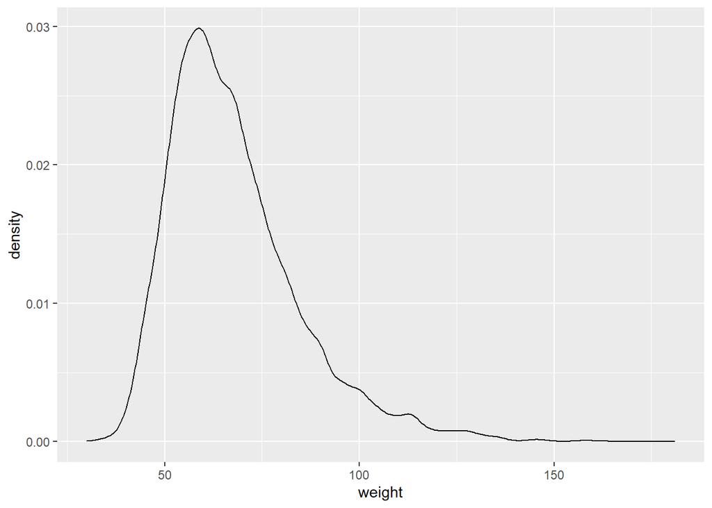

```r
yrbss%>%
  filter(!is.na(weight))%>%
  ggplot(aes(x = weight))+
  geom_density()
```

Let’s also calculate some summary statistics for `weight`.

```r
yrbss%>%
  filter(!is.na(weight))%>%
  summarise(n = n(),
            x_bar = mean(weight),
            s = sd(weight),
            min = min(weight),
            max = max(weight))
```

```
## # A tibble: 1 x 5
##       n x_bar     s   min   max
##   <int> <dbl> <dbl> <dbl> <dbl>
## 1 12579  67.9  16.9  29.9  181.
```

A recent study reported that college students have mean weight of 66.82 kg. Suppose we are interested in testing if the mean weight of all high school students in the U.S. $(\mu)$ differs from 66.82 kg. We can conduct a hypothesis test and construct a 95% confidence interval using `t_test()` function as shown below:

```r
yrbss%>%
  filter(!is.na(weight))%>%
  t_test(response = weight,
         mu = 66.82,
         conf_int = TRUE,
         conf_level = 0.95)
```

3. Set up a Hypothesis Test for testing if the mean weight of all high school students is different from 66.82 kg. Use a 5% significance level ($\alpha = 0.05$). Report the 95% confidence interval as well.

> Note: The `t_test()` is for means while the `prop_test()` is for porportions.

### Exploratory Data Analysis

Consider the possible relationship between a high schooler’s weight and their physical activity. Plotting the data is a useful first step because it helps us quickly visualize trends, identify strong associations, and develop research questions.

4. Make a side-by-side violin plots of `physical_3plus` and `weight`. Is there a relationship between these two variables? What did you expect and why?

```r
yrbss %>%
  filter(!is.na(physical_3plus), !is.na(weight))%>%
  ggplot(aes(x = physical_3plus, y = weight, fill = physical_3plus))+
  geom_violin()
```

```r
yrbss %>%
  filter(!is.na(physical_3plus), !is.na(weight))%>%
  group_by(physical_3plus) %>%
  summarise(mean_weight = mean(weight))
```

5. Is there an observed difference in students weight by their rate of physically activity? Is this difference large enough to deem it “statistically significant”?

In order to answer the previous question better using statistical tools we will conduct a hypothesis test.

6. Set up a Hypothesis Test for testing if the mean weights are not different for those who physically active at least 3 days a week and those who are not. Use a 5% significance level ($\alpha = 0.05$). Report the 95% confidence interval as well.

This work is licensed under a [Creative Commons Attribution-ShareAlike 4.0 International License](http://creativecommons.org/licenses/by-sa/4.0/).